# **Ensemble Techniques Project - Travel Package Purchase Prediction**

**Context**

Tourism company called "Visit with us" wants to enable and establish a viable business model to expand the customer base. Currently, there are 5 types of packages the company is offering - Basic, Standard, Deluxe, Super Deluxe, King. To expland more, they would like to introduce a new product package called - Wellness Tourism Package. Company wants to target the customer base who can potentially buy their newly introduced package.

**Objective**

Using ensemble techniques like Bagging and Boosing analyze the customers' data to predict which customer is more likely to purchase the newly introduced travel package.

**Data Dictionary**

**Customer details:**

CustomerID: Unique customer ID

ProdTaken: Whether the customer has purchased a package or not (0: No, 1: Yes)

Age: Age of customer

TypeofContact: How customer was contacted (Company Invited or Self Inquiry)

CityTier: City tier depends on the development of a city, population, facilities, and living standards. The categories are ordered i.e. Tier 1 > Tier 2 > Tier 3. It's the city the customer lives in.

Occupation: Occupation of customer

Gender: Gender of customer

NumberOfPersonVisiting: Total number of persons planning to take the trip with the customer

PreferredPropertyStar: Preferred hotel property rating by customer

MaritalStatus: Marital status of customer

NumberOfTrips: Average number of trips in a year by customer

Passport: The customer has a passport or not (0: No, 1: Yes)

OwnCar: Whether the customers own a car or not (0: No, 1: Yes)

NumberOfChildrenVisiting: Total number of children with age less than 5 planning to take the trip with the customer

Designation: Designation of the customer in the current organization

MonthlyIncome: Gross monthly income of the customer

**Customer interaction data**

PitchSatisfactionScore: Sales pitch satisfaction score

ProductPitched: Product pitched by the salesperson

NumberOfFollowups: Total number of follow-ups has been done by the salesperson after the sales pitch

DurationOfPitch: Duration of the pitch by a salesperson to the customer

# **1. Loading Required Libraries and Importing Data**

```python
# Importing libraries to help with reading and manipulating data
import numpy as np
import pandas as pd

# Importing Libraries to help with EDA
import matplotlib.pyplot as plt
import seaborn as sns
%matplotlib inline
sns.set()

# Removes the limit for the number of displayed columns
pd.set_option("display.max_columns", None)
# Sets the limit for the number of displayed rows
pd.set_option("display.max_rows", 500)

# to split the data into train and test
from sklearn.model_selection import train_test_split

# To build model for prediction
from sklearn.linear_model import LogisticRegression

# To tune different models
from sklearn.model_selection import GridSearchCV

# To get diferent metric scores
from sklearn.metrics import (
    f1_score,
    accuracy_score,
    recall_score,
    precision_score,
    confusion_matrix,
    roc_auc_score,
    plot_confusion_matrix,
    precision_recall_curve,
    roc_curve,
    make_scorer,
)

from sklearn.tree import DecisionTreeClassifier
from sklearn import tree
from sklearn import metrics

from sklearn.ensemble import BaggingClassifier
from sklearn.ensemble import RandomForestClassifier

from sklearn.ensemble import AdaBoostClassifier, GradientBoostingClassifier
from xgboost import XGBClassifier
from sklearn.ensemble import StackingClassifier
```

```python
# Connect to Google Drive
from google.colab import drive
drive.mount('/content/drive')
```

```python
# Create DataFrame 'tour' by importing 'Tourism' file and make a copy of it just in case if need to revert back
tour = pd.read_excel('/content/drive/My Drive/Colab Notebooks/Tourism.xlsx',sheet_name='Tourism')
tour_copy = tour.copy()
```

# **2. Exploring Data At High Level**

Check first 10 records to see the dataset at high level

```python
tour.head(10)
```

|  | CustomerID | ProdTaken | Age | TypeofContact | CityTier | DurationOfPitch | Occupation | Gender | NumberOfPersonVisiting | NumberOfFollowups | ProductPitched | PreferredPropertyStar | MaritalStatus | NumberOfTrips | Passport | PitchSatisfactionScore | OwnCar | NumberOfChildrenVisiting | Designation | MonthlyIncome |
| --- | --- | --- | --- | --- | --- | --- | --- | --- | --- | --- | --- | --- | --- | --- | --- | --- | --- | --- | --- | --- |
| 0 | 200000 | 1 | 41.0 | Self Enquiry | 3 | 6.0 | Salaried | Female | 3 | 3.0 | Deluxe | 3.0 | Single | 1.0 | 1 | 2 | 1 | 0.0 | Manager | 20993.0 |
| 1 | 200001 | 0 | 49.0 | Company Invited | 1 | 14.0 | Salaried | Male | 3 | 4.0 | Deluxe | 4.0 | Divorced | 2.0 | 0 | 3 | 1 | 2.0 | Manager | 20130.0 |
| 2 | 200002 | 1 | 37.0 | Self Enquiry | 1 | 8.0 | Free Lancer | Male | 3 | 4.0 | Basic | 3.0 | Single | 7.0 | 1 | 3 | 0 | 0.0 | Executive | 17090.0 |
| 3 | 200003 | 0 | 33.0 | Company Invited | 1 | 9.0 | Salaried | Female | 2 | 3.0 | Basic | 3.0 | Divorced | 2.0 | 1 | 5 | 1 | 1.0 | Executive | 17909.0 |
| 4 | 200004 | 0 | NaN | Self Enquiry | 1 | 8.0 | Small Business | Male | 2 | 3.0 | Basic | 4.0 | Divorced | 1.0 | 0 | 5 | 1 | 0.0 | Executive | 18468.0 |
| 5 | 200005 | 0 | 32.0 | Company Invited | 1 | 8.0 | Salaried | Male | 3 | 3.0 | Basic | 3.0 | Single | 1.0 | 0 | 5 | 1 | 1.0 | Executive | 18068.0 |
| 6 | 200006 | 0 | 59.0 | Self Enquiry | 1 | 9.0 | Small Business | Female | 2 | 2.0 | Basic | 5.0 | Divorced | 5.0 | 1 | 2 | 1 | 1.0 | Executive | 17670.0 |
| 7 | 200007 | 0 | 30.0 | Self Enquiry | 1 | 30.0 | Salaried | Male | 3 | 3.0 | Basic | 3.0 | Married | 2.0 | 0 | 2 | 0 | 1.0 | Executive | 17693.0 |
| 8 | 200008 | 0 | 38.0 | Company Invited | 1 | 29.0 | Salaried | Male | 2 | 4.0 | Standard | 3.0 | Unmarried | 1.0 | 0 | 3 | 0 | 0.0 | Senior Manager | 24526.0 |
| 9 | 200009 | 0 | 36.0 | Self Enquiry | 1 | 33.0 | Small Business | Male | 3 | 3.0 | Deluxe | 3.0 | Divorced | 7.0 | 0 | 3 | 1 | 0.0 | Manager | 20237.0 |

By looking at sample records, at a first glace data looks good and as per the data dictionary.

Let's check few basic things to understand the dataset better.

```python
# checking for dups
tour.duplicated().sum()
```

```
0
```

There are no duplicates

```python
# checking rows and columns of dataframe
tour.shape
```

```
(4888, 20)
```

There are 4888 rows and 20 columns

```python
# check datatypes and non null counts
tour.info()
```

```
<class 'pandas.core.frame.DataFrame'>
RangeIndex: 4888 entries, 0 to 4887
Data columns (total 20 columns):
 #   Column                    Non-Null Count  Dtype
---  ------                    --------------  -----
 0   CustomerID                4888 non-null   int64
 1   ProdTaken                 4888 non-null   int64
 2   Age                       4662 non-null   float64
 3   TypeofContact             4863 non-null   object
 4   CityTier                  4888 non-null   int64
 5   DurationOfPitch           4637 non-null   float64
 6   Occupation                4888 non-null   object
 7   Gender                    4888 non-null   object
 8   NumberOfPersonVisiting    4888 non-null   int64
 9   NumberOfFollowups         4843 non-null   float64
 10  ProductPitched            4888 non-null   object
 11  PreferredPropertyStar     4862 non-null   float64
 12  MaritalStatus             4888 non-null   object
 13  NumberOfTrips             4748 non-null   float64
 14  Passport                  4888 non-null   int64
 15  PitchSatisfactionScore    4888 non-null   int64
 16  OwnCar                    4888 non-null   int64
 17  NumberOfChildrenVisiting  4822 non-null   float64
 18  Designation               4888 non-null   object
 19  MonthlyIncome             4655 non-null   float64
dtypes: float64(7), int64(7), object(6)
memory usage: 763.9+ KB
```

Looks like there are some nulls in columns like age, typeofcontact etc. Also, few object columns are there and they look valid.

```python
# check some stats of columns
tour.describe(include="all").T
```

|  | count | unique | top | freq | mean | std | min | 25% | 50% | 75% | max |
| --- | --- | --- | --- | --- | --- | --- | --- | --- | --- | --- | --- |
| CustomerID | 4888.0 | NaN | NaN | NaN | 202443.5 | 1411.188388 | 200000.0 | 201221.75 | 202443.5 | 203665.25 | 204887.0 |
| ProdTaken | 4888.0 | NaN | NaN | NaN | 0.188216 | 0.390925 | 0.0 | 0.0 | 0.0 | 0.0 | 1.0 |
| Age | 4662.0 | NaN | NaN | NaN | 37.622265 | 9.316387 | 18.0 | 31.0 | 36.0 | 44.0 | 61.0 |
| TypeofContact | 4863 | 2 | Self Enquiry | 3444 | NaN | NaN | NaN | NaN | NaN | NaN | NaN |
| CityTier | 4888.0 | NaN | NaN | NaN | 1.654255 | 0.916583 | 1.0 | 1.0 | 1.0 | 3.0 | 3.0 |
| DurationOfPitch | 4637.0 | NaN | NaN | NaN | 15.490835 | 8.519643 | 5.0 | 9.0 | 13.0 | 20.0 | 127.0 |
| Occupation | 4888 | 4 | Salaried | 2368 | NaN | NaN | NaN | NaN | NaN | NaN | NaN |
| Gender | 4888 | 3 | Male | 2916 | NaN | NaN | NaN | NaN | NaN | NaN | NaN |
| NumberOfPersonVisiting | 4888.0 | NaN | NaN | NaN | 2.905074 | 0.724891 | 1.0 | 2.0 | 3.0 | 3.0 | 5.0 |
| NumberOfFollowups | 4843.0 | NaN | NaN | NaN | 3.708445 | 1.002509 | 1.0 | 3.0 | 4.0 | 4.0 | 6.0 |
| ProductPitched | 4888 | 5 | Basic | 1842 | NaN | NaN | NaN | NaN | NaN | NaN | NaN |
| PreferredPropertyStar | 4862.0 | NaN | NaN | NaN | 3.581037 | 0.798009 | 3.0 | 3.0 | 3.0 | 4.0 | 5.0 |
| MaritalStatus | 4888 | 4 | Married | 2340 | NaN | NaN | NaN | NaN | NaN | NaN | NaN |
| NumberOfTrips | 4748.0 | NaN | NaN | NaN | 3.236521 | 1.849019 | 1.0 | 2.0 | 3.0 | 4.0 | 22.0 |
| Passport | 4888.0 | NaN | NaN | NaN | 0.290917 | 0.454232 | 0.0 | 0.0 | 0.0 | 1.0 | 1.0 |
| PitchSatisfactionScore | 4888.0 | NaN | NaN | NaN | 3.078151 | 1.365792 | 1.0 | 2.0 | 3.0 | 4.0 | 5.0 |
| OwnCar | 4888.0 | NaN | NaN | NaN | 0.620295 | 0.485363 | 0.0 | 0.0 | 1.0 | 1.0 | 1.0 |
| NumberOfChildrenVisiting | 4822.0 | NaN | NaN | NaN | 1.187267 | 0.857861 | 0.0 | 1.0 | 1.0 | 2.0 | 3.0 |
| Designation | 4888 | 5 | Executive | 1842 | NaN | NaN | NaN | NaN | NaN | NaN | NaN |
| MonthlyIncome | 4655.0 | NaN | NaN | NaN | 23619.853491 | 5380.698361 | 1000.0 | 20346.0 | 22347.0 | 25571.0 | 98678.0 |

Few observations -

1) All the customers are between age 18 and 61 with average age around 38. There are some missing values.

2) Monthly income varies between 1K and 98.6K. The 75th percentile has value of 26K, so there could be some outliers. There are some missing values here.

3) Columns having boolean values (passport,Owncar, prodtaken) seems to have valid data without any missing values.

4) Gender has 3 unique values, which is odd. I would like to analyze the values before EDA.

5) columns like NumberOfChildrenVisiting, PitchSatisfactionScore, PreferredPropertyStar, NumberOfFollowups, CityTier and NumberOfPersonVisiting have very specific number of values. They have some Nulls but by looking at min and max, seem to have valid limited values.

**Pre EDA Data Pre Processing**

Customer ID can be dropped as it would not add any value in Modelling and would not be required for EDA as well. So it is better to drop at this point.

```python
# dropping ID column in original dataset
tour.drop(columns='CustomerID', inplace=True)
```

Let's analyze Gender column

```python
tour.Gender.value_counts()
```

```
Male       2916
Female     1817
Fe Male     155
Name: Gender, dtype: int64
```

There is an extra space in 155 'Female' values. We should treat that before EDA.

```python
# replacing 'Fe Male' with 'Female'
tour['Gender'] = tour['Gender'].replace(['Fe Male'],'Female')
```

```python
tour.Gender.value_counts()
```

```
Male      2916
Female    1972
Name: Gender, dtype: int64
```

Looks good

```python
# checking one more time
tour.head()
```

|  | ProdTaken | Age | TypeofContact | CityTier | DurationOfPitch | Occupation | Gender | NumberOfPersonVisiting | NumberOfFollowups | ProductPitched | PreferredPropertyStar | MaritalStatus | NumberOfTrips | Passport | PitchSatisfactionScore | OwnCar | NumberOfChildrenVisiting | Designation | MonthlyIncome |
| --- | --- | --- | --- | --- | --- | --- | --- | --- | --- | --- | --- | --- | --- | --- | --- | --- | --- | --- | --- |
| 0 | 1 | 41.0 | Self Enquiry | 3 | 6.0 | Salaried | Female | 3 | 3.0 | Deluxe | 3.0 | Single | 1.0 | 1 | 2 | 1 | 0.0 | Manager | 20993.0 |
| 1 | 0 | 49.0 | Company Invited | 1 | 14.0 | Salaried | Male | 3 | 4.0 | Deluxe | 4.0 | Divorced | 2.0 | 0 | 3 | 1 | 2.0 | Manager | 20130.0 |
| 2 | 1 | 37.0 | Self Enquiry | 1 | 8.0 | Free Lancer | Male | 3 | 4.0 | Basic | 3.0 | Single | 7.0 | 1 | 3 | 0 | 0.0 | Executive | 17090.0 |
| 3 | 0 | 33.0 | Company Invited | 1 | 9.0 | Salaried | Female | 2 | 3.0 | Basic | 3.0 | Divorced | 2.0 | 1 | 5 | 1 | 1.0 | Executive | 17909.0 |
| 4 | 0 | NaN | Self Enquiry | 1 | 8.0 | Small Business | Male | 2 | 3.0 | Basic | 4.0 | Divorced | 1.0 | 0 | 5 | 1 | 0.0 | Executive | 18468.0 |

Looks good, let's do EDA.

# **3. Exploratory Data Analysis (EDA)**

### Univariate Analysis

Let's create function to find counts/percentage of columns with continuous values to understand the data better.

```python
def histogram_boxplot(data, feature, figsize=(12, 7), kde=False, bins=None):
    """
    Boxplot and histogram combined

    data: dataframe
    feature: dataframe column
    figsize: size of figure (default (12,7))
    kde: whether to show the density curve (default False)
    bins: number of bins for histogram (default None)
    """
    f2, (ax_box2, ax_hist2) = plt.subplots(
        nrows=2,  # Number of rows of the subplot grid= 2
        sharex=True,  # x-axis will be shared among all subplots
        gridspec_kw={"height_ratios": (0.25, 0.75)},
        figsize=figsize)  # creating the 2 subplots

    sns.boxplot(data=data, x=feature, ax=ax_box2, showmeans=True, color="violet")  # boxplot will be created and a star will indicate the mean value of the column

    if bins:
      sns.histplot(data=data, x=feature, kde=kde, ax=ax_hist2, bins=bins, palette="winter")
    else:
      sns.histplot(data=data, x=feature, kde=kde, ax=ax_hist2)  # For histogram

    ax_hist2.axvline(data[feature].mean(), color="green", linestyle="--")  # Add mean to the histogram

    ax_hist2.axvline(data[feature].median(), color="black", linestyle="-")  # Add median to the histogram
```

**Age**

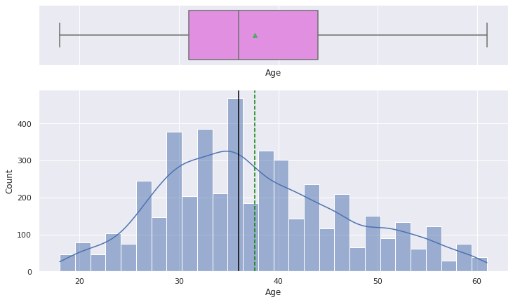

```python
histogram_boxplot(tour,'Age',kde=True)
```

Age is kind of normalized with maximum number of customers around 35.

**MonthlyIncome**

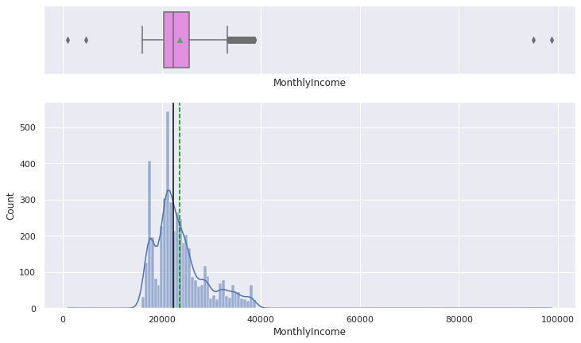

```python
histogram_boxplot(tour,'MonthlyIncome',kde=True)
```

Monthly income is right skewed with some outliers at the left and right whiskers.

**DurationOfPitch**

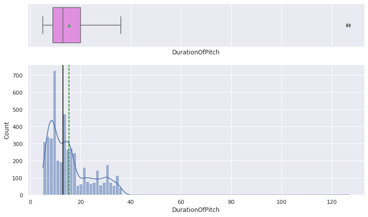

```python
histogram_boxplot(tour,'DurationOfPitch',kde=True)
```

I assume the pitch is in number of minutes. Most of pitches around 10-15min with some outliers after the right whisker.

**NumberOfTrips**

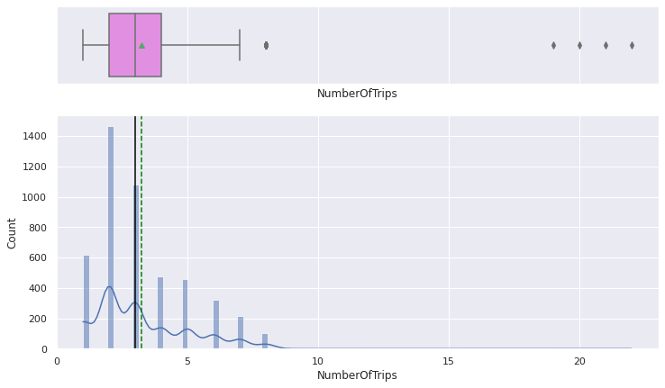

```python
histogram_boxplot(tour,'NumberOfTrips',kde=True)
```

Most of the trips are under 8 with few way more than 18.

Let's create function to find counts/percentage of columns which supposed to have categorical data or data with handful of unique values to understand them better and find out if any bad data is there.

```python
# function to create labeled countplots

def labeled_countplot(data, feature, hue=None, perc=False, n=None):
    """
    Barplot with percentage at the top

    data: dataframe
    feature: dataframe column
    perc: whether to display percentages instead of count (default is False)
    n: displays the top n category levels (default is None, i.e., display all levels)
    """

    total = len(data[feature])  # length of the column
    count = data[feature].nunique()
    if n is None:
        plt.figure(figsize=(count + 1, 5))
    else:
        plt.figure(figsize=(n + 1, 5))

    plt.xticks(rotation=90, fontsize=15)
    if hue==None:
      ax = sns.countplot(
        data=data,
        x=feature,
        palette="Paired",
        order=data[feature].value_counts().index[:n].sort_values(),
      )
    else:
      ax = sns.countplot(
        data=data,
        x=feature,
        hue=hue,
        palette="Paired",
        order=data[feature].value_counts().index[:n].sort_values(),
      )

    for p in ax.patches:
        if perc == True:
            label = "{:.1f}%".format(
                100 * p.get_height() / total
            )  # percentage of each class of the category
        else:
            label = p.get_height()  # count of each level of the category

        x = p.get_x() + p.get_width() / 2  # width of the plot
        y = p.get_height()  # height of the plot

        ax.annotate(
            label,
            (x, y),
            ha="center",
            va="center",
            size=12,
            xytext=(0, 5),
            textcoords="offset points",
        )  # annotate the percentage

    plt.show()  # show the plot
```

Let's map all categorical columns

**TypeofContact**

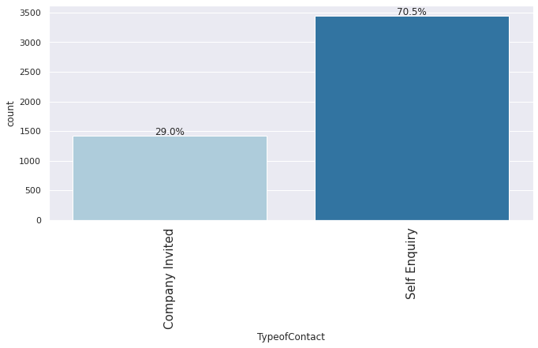

```python
labeled_countplot(tour,'TypeofContact',perc=True, n=10)
```

No bad data. More than 70% of customers are 'self inquiry'

**Occupation**

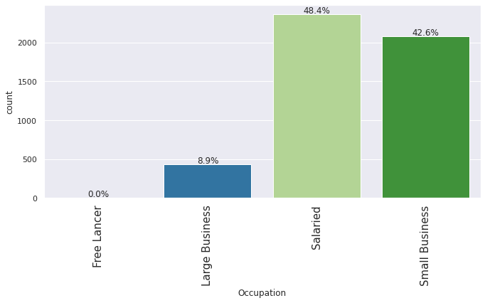

```python
labeled_countplot(tour,'Occupation', perc=True,n=10)
```

No bad data. Almost 90% customers are either 'salaried' or having 'small business'.

**Gender**

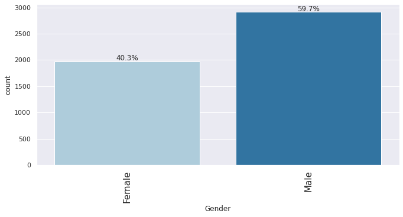

```python
labeled_countplot(tour,'Gender', perc=True, n=10)
```

Male and Female are 60-40 ratio. After cleaning up Female customers, there are no other bad data here.

**Product Pitched**

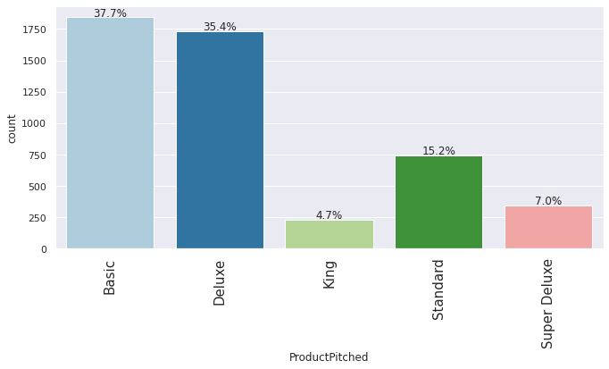

```python
labeled_countplot(tour,'ProductPitched', perc=True, n=10)
```

No bad data. More than 70% pitches done by sales persons were about 'Basic' and 'Deluxe' products.

**Marital Status**

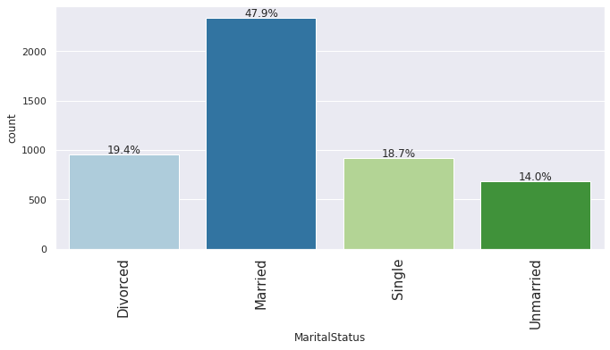

```python
labeled_countplot(tour,'MaritalStatus', perc=True, n=10)
```

**Designation**

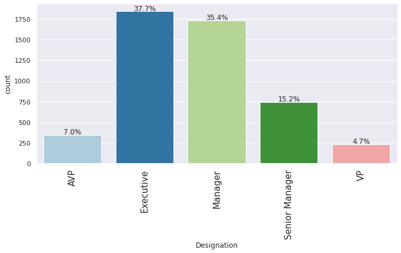

```python
labeled_countplot(tour,'Designation', perc=True, n=10)
```

No bad data. More than 70% customers were either 'Executive' or ' Manager'

Let's map numeric columns with handful of unique values.

**CityTier**

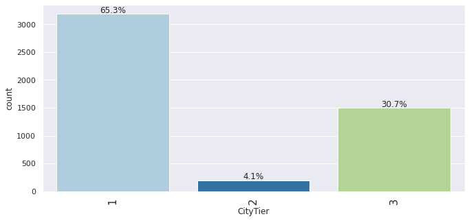

```python
labeled_countplot(tour,'CityTier', perc=True,n=10)
```

No bad data. More than 65% customers are from tier 1 cities and more than 30% from tier 3 city. For some reason, tier 2 customers are very less (<5%).

**PitchSatisfactionScore**

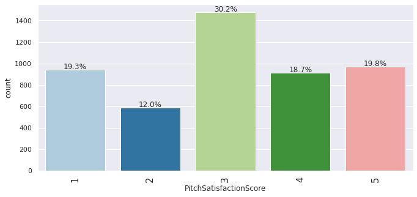

```python
labeled_countplot(tour,'PitchSatisfactionScore', perc=True,n=10)
```

No bad data. Pitch satisfiction score is kind of divided well across 1 to 5 with majority score at 3.

**PreferredPropertyStar**

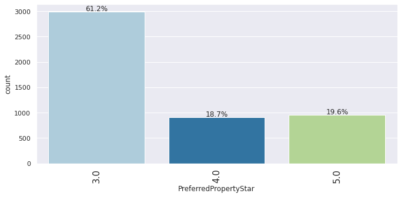

```python
labeled_countplot(tour,'PreferredPropertyStar', perc=True,n=10)
```

No bad data. Customers preferred hotels were 3 or above with majority at 3. They do not prefer less than 3 stars.

**NumberOfFollowups**

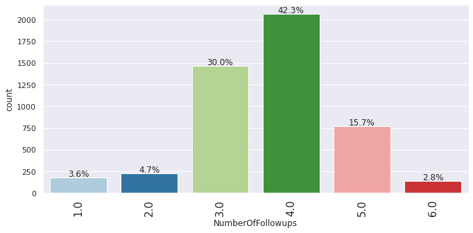

```python
labeled_countplot(tour,'NumberOfFollowups', perc=True,n=10)
```

No bad data. Sales person followed up 1 to 6 times after the sales pitch with maximum time of 4 followed by 3.

**NumberOfPersonVisiting**

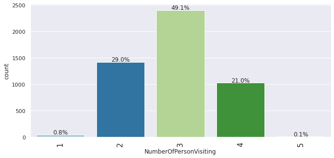

```python
labeled_countplot(tour,'NumberOfPersonVisiting', perc=True,n=10)
```

No bad data. Almost 50% of the customers go on trip with 3 people.

**NumberOfChildrenVisiting**

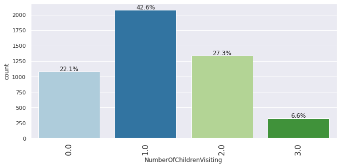

```python
labeled_countplot(tour,'NumberOfChildrenVisiting', perc=True,n=10)
```

No bad data. Around 42% customers have 1 child less than 5 years of age.

Let's map columns with boolean variables

**OwnCar**

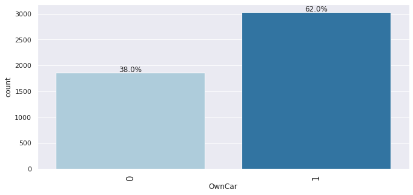

```python
labeled_countplot(tour,'OwnCar', perc=True, n=10)
```

No bad data. More than 60% customers own car.

**ProdTaken**

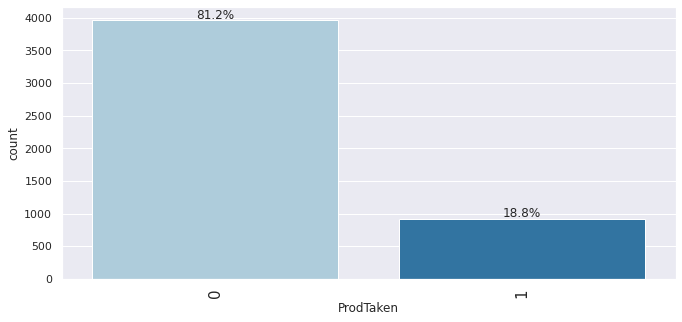

```python
labeled_countplot(tour,'ProdTaken', perc=True, n=10)
```

No bad data. Around 81% customers didn't take any packages.

**Passport**

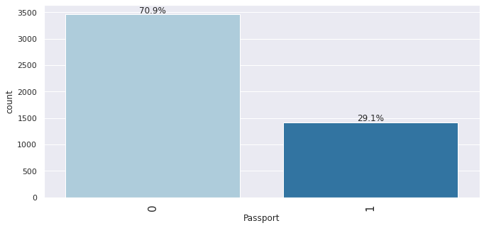

```python
labeled_countplot(tour,'Passport', perc=True, n=10)
```

No bad data. Almost 71% customers do not have passport.

### Bivariate Analysis

Let's start by finding the correlations between different columns to get generic idea.

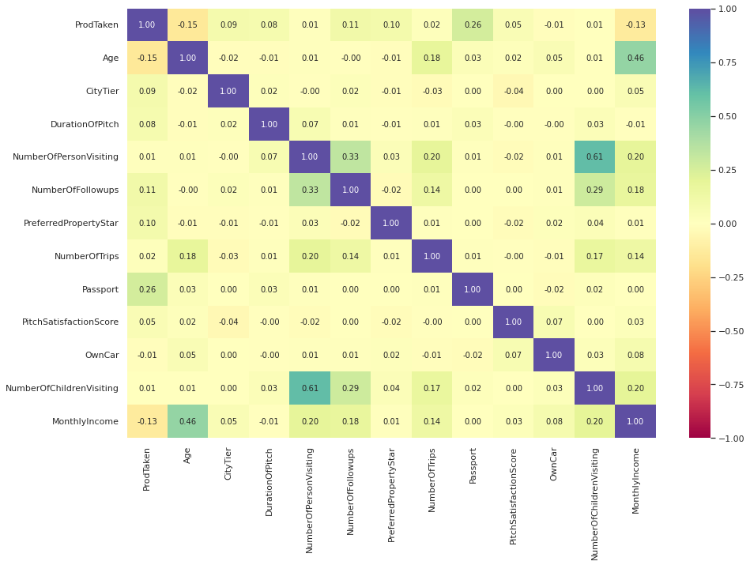

```python
plt.figure(figsize=(15, 10))
sns.heatmap(
    tour.corr(), annot=True, vmin=-1, vmax=1, fmt=".2f", cmap="Spectral"
)
plt.show()
```

Few observations -

1) Age and MonthlyIncome are positively correlated and it kind of makes sense. Also, it means customers are working consistantly well to increase their income.

2) NumberOfPersonVisiting is highly positively correlated with NumberOfChilderVisiting. It means, most of the customers go with their children(family).

3) ProdTaken is slightly negatively correlated with MonthlyIncome and Age.

4) NumberOfFollowups is positively correlated with NumberOfPersonVisiting and NumberOfChildernVisiting, so more follow ups slightly increase the chance of customer taking package.

Let's create a function to plot stacked barplot to check columns with less distinct values (including boolean) and see their affect on ProdTaken column.

```python
# function to plot stacked bar chart

def stacked_barplot(data, predictor, target):
    """
    Print the category counts and plot a stacked bar chart

    data: dataframe
    predictor: independent variable
    target: target variable
    """
    count = data[predictor].nunique()
    sorter = data[target].value_counts().index[-1]
    tab1 = pd.crosstab(data[predictor], data[target], margins=True).sort_values(
        by=sorter, ascending=False
    )
    print(tab1)
    print("-" * 120)
    tab = pd.crosstab(data[predictor], data[target], normalize="index").sort_values(
        by=sorter, ascending=False
    )
    tab.plot(kind="bar", stacked=True, figsize=(count + 5, 6))
    plt.legend(
        loc="lower left", frameon=False,
    )
    plt.legend(loc="upper left", bbox_to_anchor=(1, 1))
    plt.show()
```

**CityTier vs. ProdTaken**

```
ProdTaken     0    1   All
CityTier
All        3968  920  4888
1          2670  520  3190
3          1146  354  1500
2           152   46   198
------------------------------------------------------------------------------------------------------------------------
```

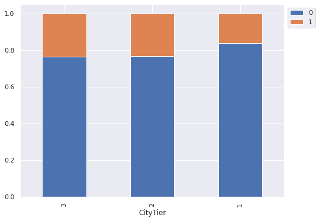

```python
stacked_barplot(tour,'CityTier','ProdTaken')
```

Customers living in citytier 2 and 3 take more tour packages compare to city tier 1 customers.

**Gender vs. ProdTaken**

```
ProdTaken     0    1   All
Gender
All        3968  920  4888
Male       2338  578  2916
Female     1630  342  1972
------------------------------------------------------------------------------------------------------------------------
```

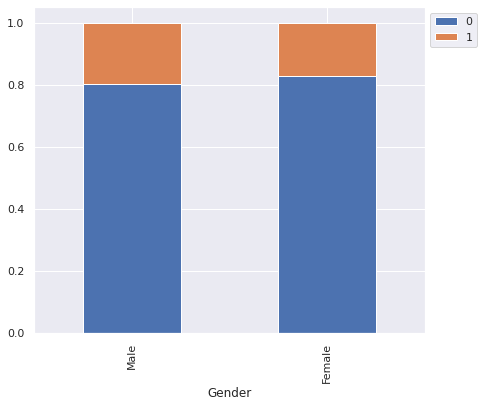

```python
stacked_barplot(tour,'Gender','ProdTaken')
```

Male customers slightly buy more tour packages than Female.

**Occupation vs. ProdTaken**

```
ProdTaken          0    1   All
Occupation
All             3968  920  4888
Salaried        1954  414  2368
Small Business  1700  384  2084
Large Business   314  120   434
Free Lancer        0    2     2
------------------------------------------------------------------------------------------------------------------------
```

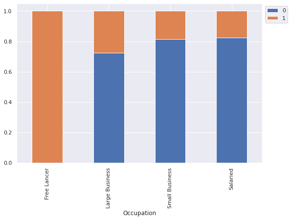

```python
stacked_barplot(tour,'Occupation','ProdTaken')
```

All Free Lancers take tour packages, however there are only 2. Other than that customers with large businesses take more tour packages compare to small businesses and salaried customers.

**NumberOfChildrenVisiting vs. ProdTaken**

```
ProdTaken                    0    1   All
NumberOfChildrenVisiting
All                       3909  913  4822
1.0                       1688  392  2080
2.0                       1082  253  1335
0.0                        880  202  1082
3.0                        259   66   325
------------------------------------------------------------------------------------------------------------------------
```

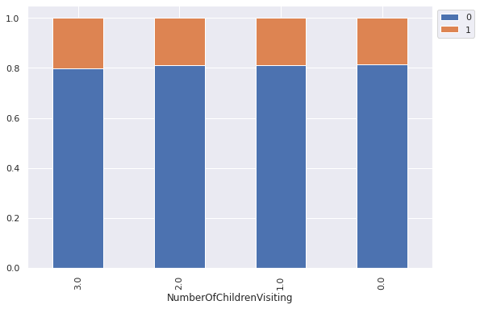

```python
stacked_barplot(tour,'NumberOfChildrenVisiting','ProdTaken')
```

Number of Children really do not affect the tour packages bought by customers.

**Owncar vs. ProdTaken**

```
ProdTaken     0    1   All
OwnCar
All        3968  920  4888
1          2472  560  3032
0          1496  360  1856
------------------------------------------------------------------------------------------------------------------------
```

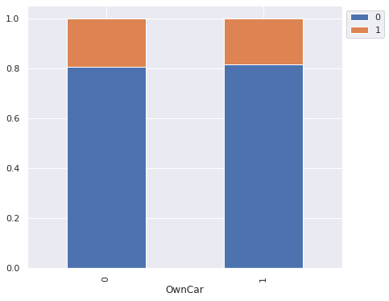

```python
stacked_barplot(tour,'OwnCar','ProdTaken')
```

Owning a car doesn't really affect tour packages bought by customers.

**NumberOfPersonVisiting vs. ProdTaken**

```
ProdTaken                  0    1   All
NumberOfPersonVisiting
All                     3968  920  4888
3                       1942  460  2402
2                       1151  267  1418
4                        833  193  1026
1                         39    0    39
5                          3    0     3
------------------------------------------------------------------------------------------------------------------------
```

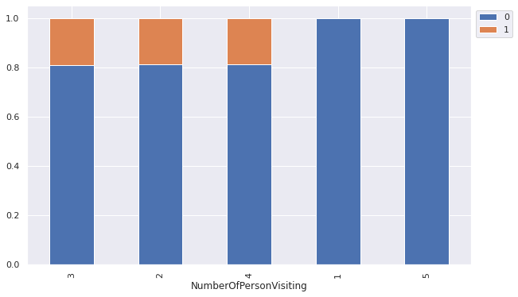

```python
stacked_barplot(tour,'NumberOfPersonVisiting','ProdTaken')
```

Not a single customer, travelling alone or with 5 people bought tour packages in the past. Customers travelling with 2,3 or 4 people took almost same percentage of tour packages.

**NumberOfFollowups vs. ProdTaken**

```
ProdTaken             0    1   All
NumberOfFollowups
All                3931  912  4843
4.0                1689  379  2068
3.0                1222  244  1466
5.0                 577  191   768
6.0                  82   54   136
2.0                 205   24   229
1.0                 156   20   176
------------------------------------------------------------------------------------------------------------------------
```

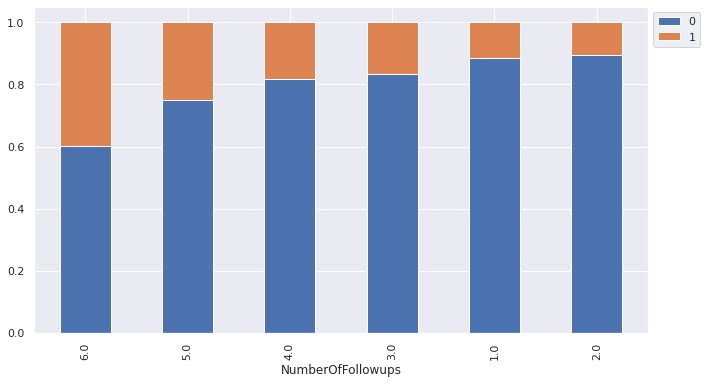

```python
stacked_barplot(tour,'NumberOfFollowups','ProdTaken')
```

It clearly shows by doing more follow ups by sales team, more tour packages were sold.

**Passport vs. ProdTaken**

```
ProdTaken     0    1   All
Passport
All        3968  920  4888
1           928  494  1422
0          3040  426  3466
------------------------------------------------------------------------------------------------------------------------
```

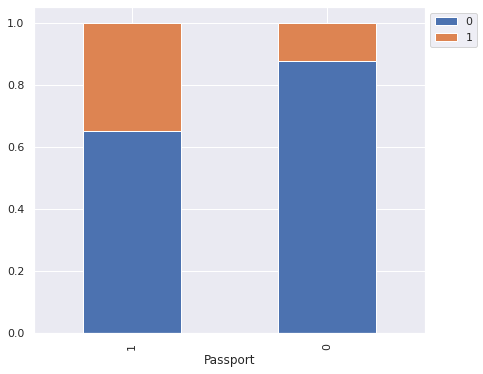

```python
stacked_barplot(tour,'Passport','ProdTaken')
```

Customers with Passport tend to buy more tour packages.

**PreferredPropertyStar vs. ProdTaken**

```
ProdTaken                 0    1   All
PreferredPropertyStar
All                    3948  914  4862
3.0                    2511  482  2993
5.0                     706  250   956
4.0                     731  182   913
------------------------------------------------------------------------------------------------------------------------
```

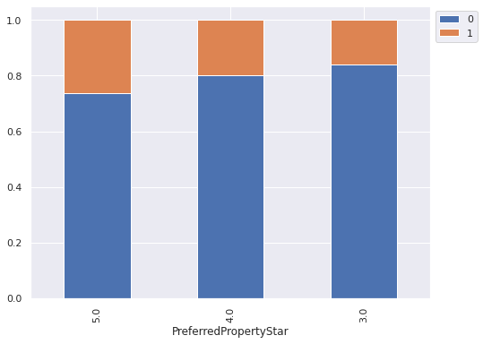

```python
stacked_barplot(tour,'PreferredPropertyStar','ProdTaken')
```

Customers who prefer 5 star hotels buy more tour packages compare to customers with 3 or 4 stars.

**PitchSatisfactionScore vs. ProdTaken**

```
ProdTaken                  0    1   All
PitchSatisfactionScore
All                     3968  920  4888
3                       1162  316  1478
5                        760  210   970
4                        750  162   912
1                        798  144   942
2                        498   88   586
------------------------------------------------------------------------------------------------------------------------
```

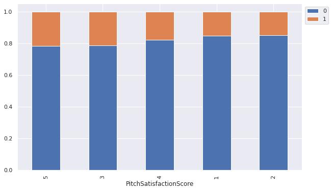

```python
stacked_barplot(tour,'PitchSatisfactionScore','ProdTaken')
```